# COVID19 Data Near Kosciusko County

Compiled by Dr. Ryan Johnson using data from (Guidotti and Ardia 2020)

Last updated Friday, May 08, 2020

#### All counts will be reported as per 80,000 because that is roughly the population of Kosciusko County.

# Indiana State Data

### Hospitalizations

Govenor Holcomb as decided that hopspitalization numbers are one of the most important indicators for how we are doing.

This graph starts much later than the others because hospitalization numbers were not reported until April 25.

The blue dashed lines are smoothed weighted averages.

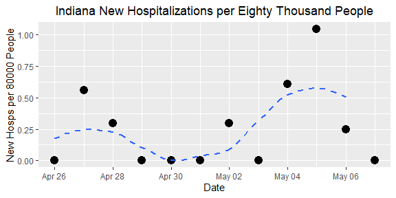

### Cases

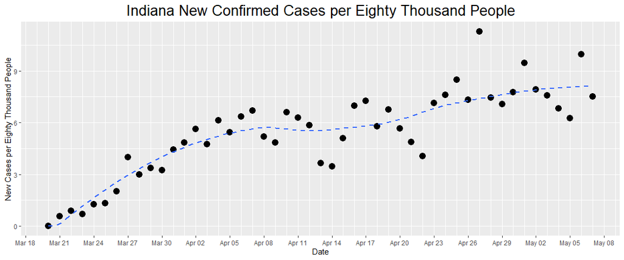

### Deaths

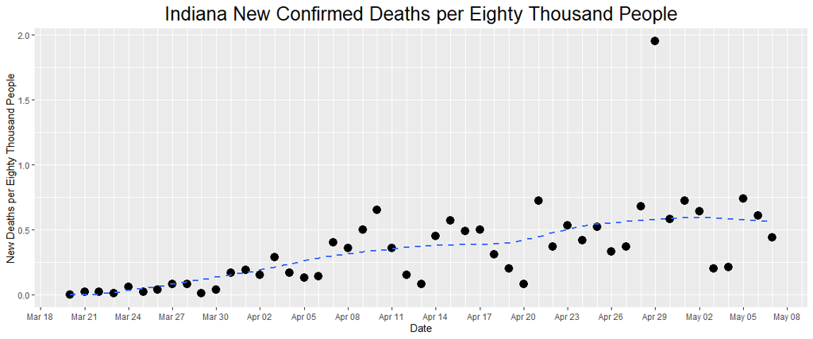

# Kosciusko Data

Note that the y-axis scales of these graphs are different than the state-level data.

### Cases

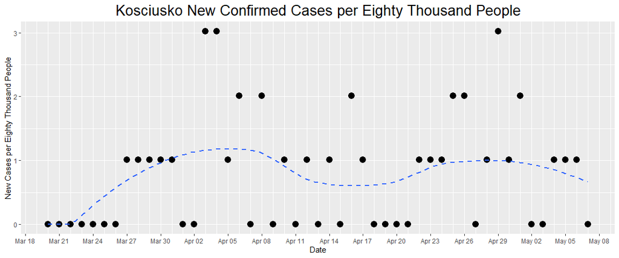

### Deaths

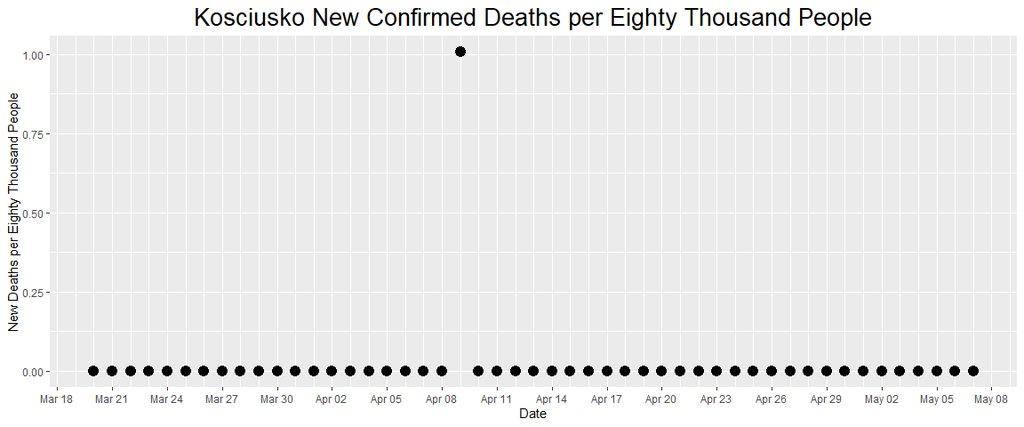

# Indiana Outbreaks

### Cases

The chart below does not contain two outliers for Cass County. On April 26th, Cass County reported 271 new cases (575 per 80,000), and on April 27th, Cass County reported 439 new cases (932 per 80,000).

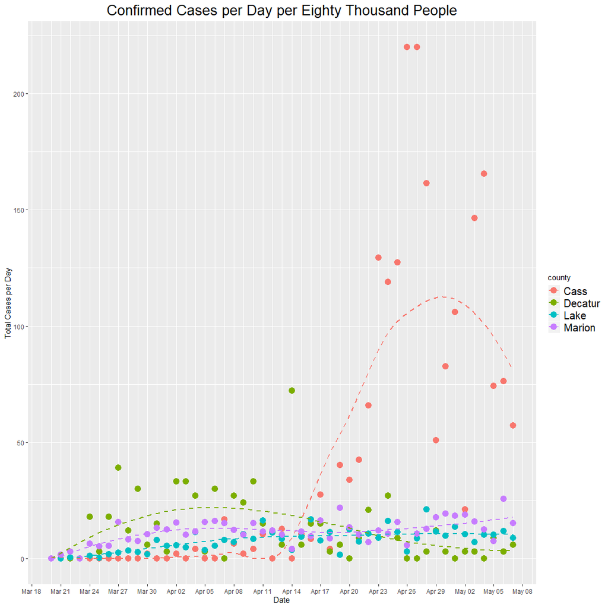

### Deaths

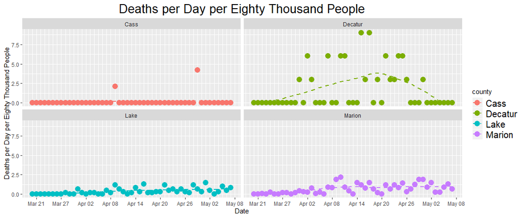

# Neighboring Counties

### Cases

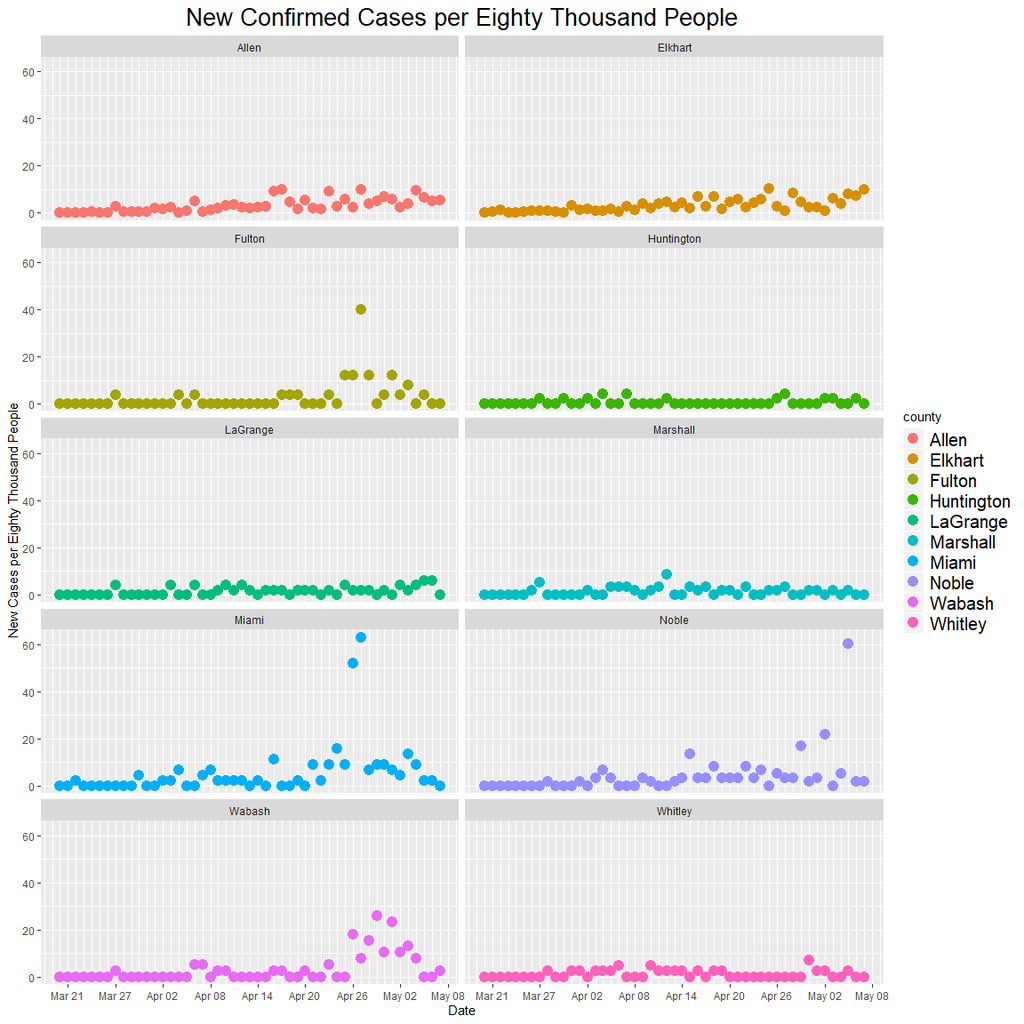

### Deaths

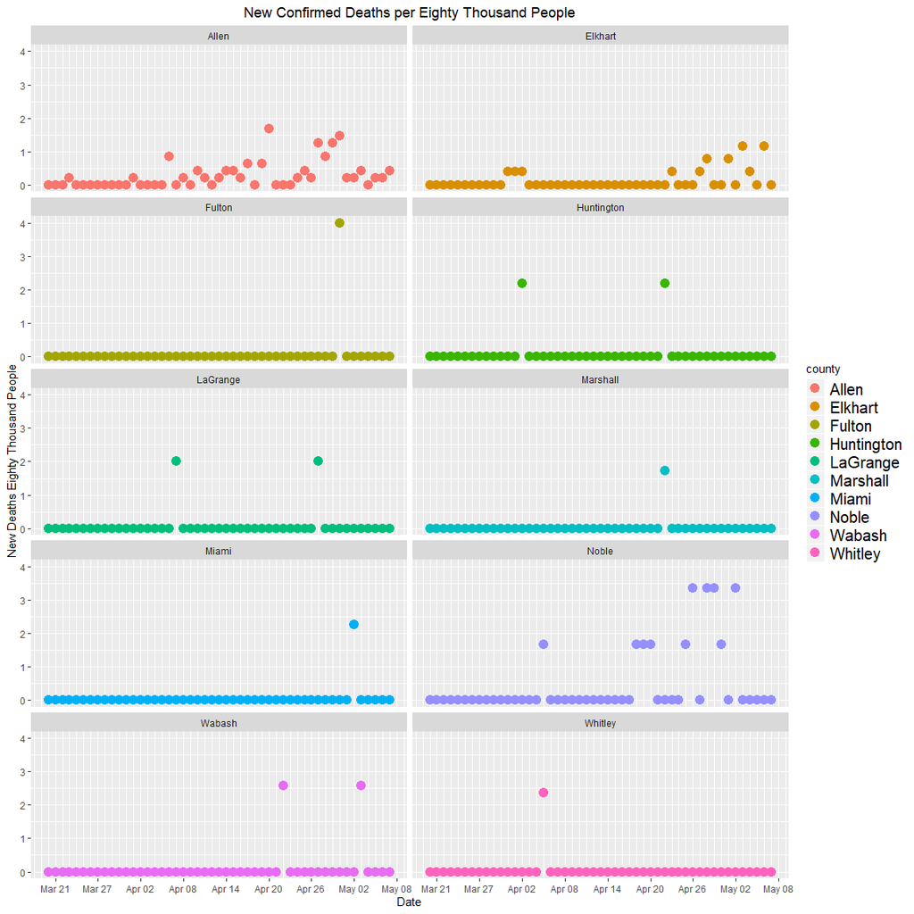

# Neighboring States Data

### Cases For Each Neighboring State

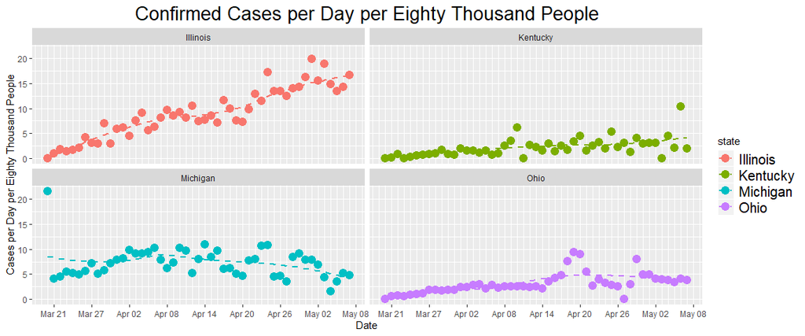

### Comparison of Smoothed Weighted Average of States

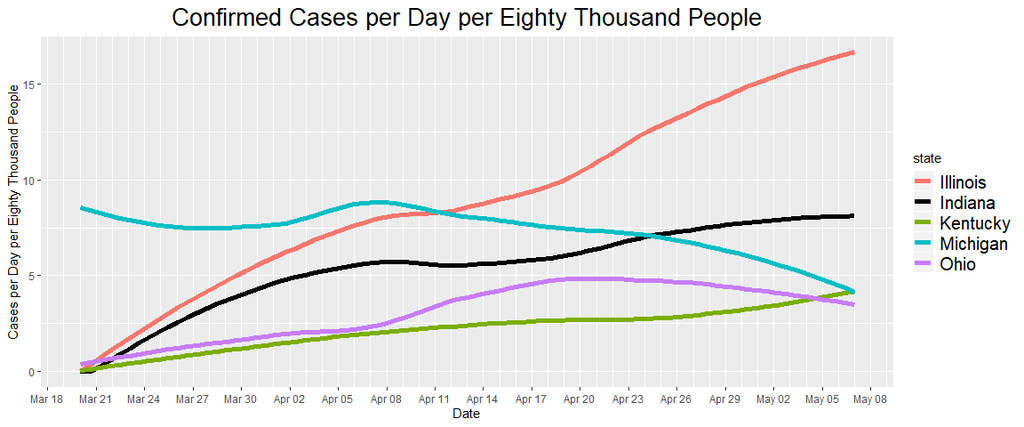

### Confirmed Deaths for Each State

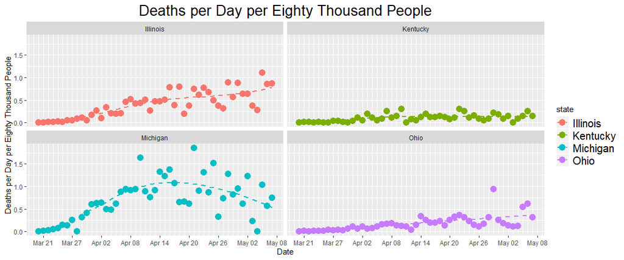

### Comparison of Smoothed Weighted Average of States

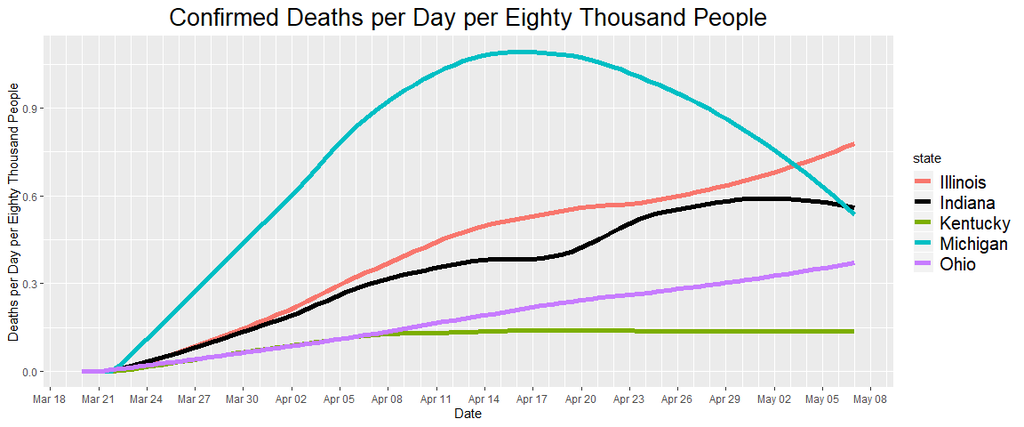

### Positive Test Rate

Looking at the percentage of tests that come back positive can signal which states might have low case numbers because of lack of testing.

For example, Michigan had a much higher death rate per capita than Illinois in mid-April, even though their case numbers per capita were only a little higher in late March and early April. Michigan’s high postive test rate late March and early April suggests that Michigan had worse testing than Illinois during that time.

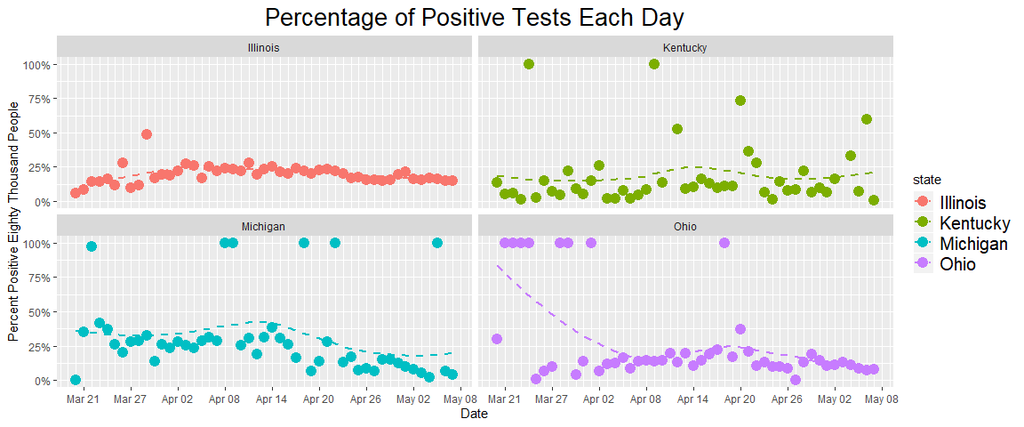

### Comparison of Smoothed Weighted Average of States

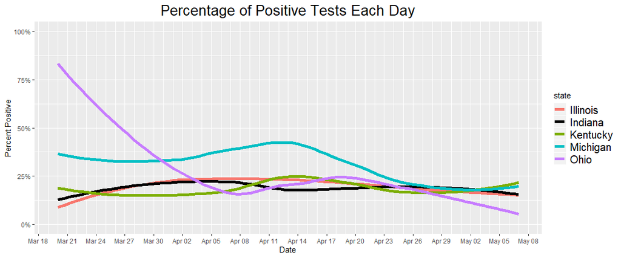

Guidotti, Emanuele, and David Ardia. 2020. “COVID-19 Data Hub.” https://doi.org/10.13140/RG.2.2.11649.81763.